# Analisis de comunidades- Vegan

Julian Avila-Jimenez

28/9/2020

### Calculo de indice de disimilaridad

Existen diversos indices de disimilaridad para el analisis de comunidades basados en distancias estadisticas multidimensionales que permiten hacer comparaciones entre comunidades en funcion de las especies que las componen. En este ejercicio vamos a comparar diferentes sitios de estudio en funcion de la abundancia de las especies encontradas, primero hallamos un indice de disimilaridad de las comunidades *Bray–Curtis* y luego realizaremos un analisis de similitud *anosim* tomando la matriz de disimilitud y una variable discreta del set de datos ambiental.

#### Usando el tipo de manejo tenemos:

```r
dune.dist<- vegdist(dune) #calculo de matriz de distancias. por defecto Bray–Curtis

dune.ano<- anosim(dune.dist, dune.env$Management)
summary(dune.ano)
```

```
##
## Call:
## anosim(x = dune.dist, grouping = dune.env$Management)
## Dissimilarity: bray
##
## ANOSIM statistic R: 0.2579
##       Significance: 0.013
##
## Permutation: free
## Number of permutations: 999
##
## Upper quantiles of permutations (null model):
##   90%   95% 97.5%   99%
## 0.121 0.169 0.218 0.264
##
## Dissimilarity ranks between and within classes:
##         0%   25%    50%     75%  100%   N
## Between  4 58.50 104.00 145.500 188.0 147
## BF       5 15.25  25.50  41.250  57.0   3
## HF       1  7.25  46.25  68.125  89.5  10
## NM       6 64.75 124.50 156.250 181.0  15
## SF       3 32.75  53.50  99.250 184.0  15
```

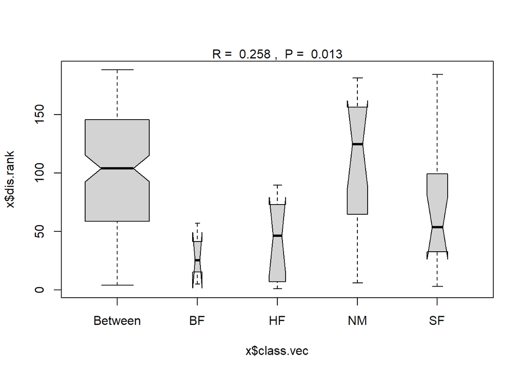

```r
plot(dune.ano)
```

El valor de la significancia nos muestra que existen comunidades que son diferentes entre si (no debe interpretarse como que todas las comunidades son diferentes).

Notese en el grafico que la comparacion debe realizarse entre cada uno de los grupos (Management) vs. todos los grupos (conjunto de todas las distancias), las cunas representan intervalos de confianza de 95% y cuando estas se sobreponen con las del grupo Between podemos inferir que no hay diferencia entre los grupos. En este caso encontramos diferencias en los grupos *BF*, *HF* y *SF*.

### Analisis de porcentaje de similaridad

Este analisis nos permite ver cuales son las especies que generan diferencias entre los grupos y cual es el aporte de cada una de estas a la diferencia, el analisis se realiza en forma de contrastes entre grupos, asi podemos ver que tan diferente es un grupo particular de otro.

```r
sim<- simper(dune, dune.env$Management)
summary(sim)
```

```
##
## Contrast: SF_BF
##
##           average       sd  ratio    ava    avb  cumsum
## Agrostol 0.061374 0.034193 1.7949 4.6667 0.0000 0.09824
## Alopgeni 0.052667 0.036476 1.4439 4.3333 0.6667 0.18255
## Lolipere 0.048116 0.039445 1.2198 3.0000 6.0000 0.25957
## Trifrepe 0.046297 0.025525 1.8138 1.3333 4.6667 0.33368
## Poatriv  0.046020 0.033801 1.3615 4.6667 3.6667 0.40734
## Scorautu 0.043697 0.024922 1.7534 1.3333 4.3333 0.47729
## Bromhord 0.033677 0.025860 1.3023 0.5000 2.6667 0.53120
## Achimill 0.030152 0.020821 1.4482 0.1667 2.3333 0.57947
## Planlanc 0.028585 0.021549 1.3265 0.0000 2.0000 0.62522
## Elymrepe 0.028074 0.029778 0.9428 2.0000 1.3333 0.67016
## Bracruta 0.025501 0.023902 1.0669 2.0000 2.0000 0.71098
## Poaprat  0.025129 0.023967 1.0485 2.5000 4.0000 0.75121
## Sagiproc 0.024326 0.022149 1.0983 1.8333 0.6667 0.79014
## Bellpere 0.019859 0.017088 1.1622 0.6667 1.6667 0.82193
## Eleopalu 0.018611 0.042958 0.4333 1.3333 0.0000 0.85172
## Anthodor 0.017543 0.025804 0.6798 0.0000 1.3333 0.87981
## Juncbufo 0.016031 0.023708 0.6762 1.1667 0.0000 0.90547
## Vicilath 0.014671 0.013306 1.1026 0.0000 1.0000 0.92895
## Hyporadi 0.010286 0.015198 0.6768 0.0000 0.6667 0.94542
## Ranuflam 0.009306 0.013595 0.6845 0.6667 0.0000 0.96031
## Juncarti 0.006979 0.016109 0.4333 0.5000 0.0000 0.97148
## Callcusp 0.006979 0.016109 0.4333 0.5000 0.0000 0.98266
## Rumeacet 0.004526 0.010444 0.4333 0.3333 0.0000 0.98990
## Cirsarve 0.003983 0.009185 0.4336 0.3333 0.0000 0.99628
## Chenalbu 0.002326 0.005370 0.4333 0.1667 0.0000 1.00000
## Airaprae 0.000000 0.000000    NaN 0.0000 0.0000 1.00000
## Comapalu 0.000000 0.000000    NaN 0.0000 0.0000 1.00000
## Empenigr 0.000000 0.000000    NaN 0.0000 0.0000 1.00000
## Salirepe 0.000000 0.000000    NaN 0.0000 0.0000 1.00000
## Trifprat 0.000000 0.000000    NaN 0.0000 0.0000 1.00000
##
## Contrast: SF_HF
##
##           average       sd  ratio    ava avb  cumsum
## Agrostol 0.047380 0.031273 1.5151 4.6667 1.4 0.08351
## Alopgeni 0.046433 0.032897 1.4115 4.3333 1.6 0.16535
```

[output cut: 151 more lines]

```
## Juncbufo 0.018181 0.024648 0.7376 1.2 0.0000 0.83880
## Hyporadi 0.017141 0.026548 0.6457 0.0 1.1667 0.86255
## Callcusp 0.016833 0.024901 0.6760 0.0 1.1667 0.88587
## Achimill 0.016555 0.014900 1.1111 1.2 0.3333 0.90881
## Sagiproc 0.015282 0.016535 0.9243 0.8 0.5000 0.92998
## Airaprae 0.012605 0.018243 0.6910 0.0 0.8333 0.94744
## Bromhord 0.012094 0.015169 0.7973 0.8 0.0000 0.96420
## Comapalu 0.010105 0.014556 0.6942 0.0 0.6667 0.97820
## Bellpere 0.008801 0.013732 0.6409 0.4 0.3333 0.99039
## Empenigr 0.004536 0.010325 0.4393 0.0 0.3333 0.99668
## Vicilath 0.002399 0.005461 0.4393 0.0 0.1667 1.00000
## Chenalbu 0.000000 0.000000    NaN 0.0 0.0000 1.00000
## Cirsarve 0.000000 0.000000    NaN 0.0 0.0000 1.00000
## Permutation: free
## Number of permutations: 0
```

#### Usando el uso tenemos:

```r
dune.ano<- anosim(dune.dist, dune.env$Use)
summary(dune.ano)
```

```
##
## Call:
## anosim(x = dune.dist, grouping = dune.env$Use)
## Dissimilarity: bray
##
## ANOSIM statistic R: 0.05046
##       Significance: 0.254
##
## Permutation: free
## Number of permutations: 999
##
## Upper quantiles of permutations (null model):
##   90%   95% 97.5%   99%
## 0.107 0.146 0.183 0.219
##
## Dissimilarity ranks between and within classes:
##            0%    25%    50%     75% 100%   N
## Between   1.0 45.500  98.50 145.500  188 131
## Hayfield 15.0 68.000 107.00 134.000  181  21
## Haypastu  3.0 36.250  80.25 117.875  188  28
## Pasture  27.5 53.875  63.50 158.375  167  10
```

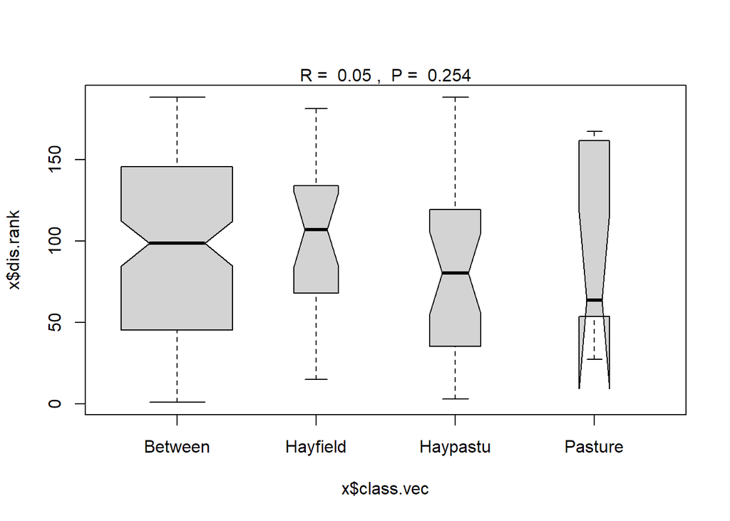

```r
plot(dune.ano)
```

En este caso el valor de p y el grafico nos indica que en terminos de uso no hay diferencias entre los grupos.

```r
sim<- simper(dune, dune.env$Use)
summary(sim)
```

```
##
## Contrast: Haypastu_Hayfield
##
##           average       sd  ratio   ava    avb  cumsum
## Poatriv  0.055255 0.043137 1.2809 4.625 2.1429 0.08239
## Lolipere 0.050354 0.043090 1.1686 3.625 1.7143 0.15748
## Agrostol 0.044052 0.037897 1.1624 3.125 1.1429 0.22317
## Alopgeni 0.043356 0.044548 0.9732 3.000 0.4286 0.28782
## Anthodor 0.034739 0.032927 1.0550 0.375 2.2857 0.33962
## Bracruta 0.034551 0.030189 1.1445 2.250 2.7143 0.39114
## Elymrepe 0.034283 0.033794 1.0145 2.000 1.4286 0.44226
## Poaprat  0.030980 0.025271 1.2259 2.750 2.0000 0.48845
## Planlanc 0.029905 0.026591 1.1246 0.625 1.8571 0.53305
## Trifrepe 0.029817 0.023936 1.2457 2.375 2.1429 0.57751
## Scorautu 0.025736 0.028326 0.9086 2.250 3.2857 0.61588
## Salirepe 0.024668 0.030874 0.7990 0.000 1.5714 0.65267
## Sagiproc 0.023017 0.025613 0.8986 1.375 0.7143 0.68699
## Rumeacet 0.021550 0.028800 0.7483 1.000 1.0000 0.71912
## Juncarti 0.019593 0.027173 0.7211 0.375 1.1429 0.74834
## Achimill 0.019478 0.018795 1.0364 0.750 1.1429 0.77738
## Bromhord 0.018216 0.023106 0.7883 0.875 0.8571 0.80455
## Eleopalu 0.017683 0.033539 0.5272 0.625 0.5714 0.83091
## Juncbufo 0.017533 0.025943 0.6758 0.875 0.5714 0.85706
## Hyporadi 0.016928 0.029300 0.5777 0.000 1.0000 0.88230
## Bellpere 0.015810 0.016255 0.9726 0.875 0.8571 0.90588
## Ranuflam 0.014848 0.021865 0.6791 0.500 0.5714 0.92802
## Airaprae 0.012524 0.020556 0.6093 0.000 0.7143 0.94669
## Trifprat 0.010741 0.021097 0.5091 0.625 0.2857 0.96271
## Callcusp 0.006605 0.016585 0.3983 0.000 0.4286 0.97256
## Comapalu 0.004609 0.012582 0.3663 0.250 0.0000 0.97943
## Empenigr 0.004404 0.011057 0.3983 0.000 0.2857 0.98600
## Vicilath 0.004203 0.006896 0.6094 0.000 0.2857 0.99226
## Cirsarve 0.003253 0.008777 0.3707 0.250 0.0000 0.99711
## Chenalbu 0.001936 0.005247 0.3689 0.125 0.0000 1.00000
##
## Contrast: Haypastu_Pasture
##
##           average       sd  ratio   ava avb  cumsum
## Poatriv  0.049381 0.038413 1.2855 4.625 2.2 0.08118
## Lolipere 0.048219 0.044834 1.0755 3.625 3.4 0.16045
```

[output cut: 49 more lines]

```
## Rumeacet 0.018056 0.02431 0.7426 1.0000 0.6 0.82918
## Achimill 0.017924 0.02050 0.8744 1.1429 0.4 0.85627
## Sagiproc 0.015974 0.01737 0.9196 0.7143 0.8 0.88042
## Bromhord 0.014052 0.01913 0.7346 0.8571 0.4 0.90166
## Airaprae 0.012622 0.02048 0.6164 0.7143 0.0 0.92074
## Bellpere 0.012234 0.01461 0.8376 0.8571 0.0 0.93923
## Juncbufo 0.011769 0.01920 0.6131 0.5714 0.4 0.95702
## Vicilath 0.008809 0.01190 0.7406 0.2857 0.4 0.97033
## Trifprat 0.007942 0.01288 0.6164 0.2857 0.4 0.98234
## Comapalu 0.007235 0.01503 0.4814 0.0000 0.4 0.99328
## Empenigr 0.004449 0.01112 0.4002 0.2857 0.0 1.00000
## Chenalbu 0.000000 0.00000    NaN 0.0000 0.0 1.00000
## Cirsarve 0.000000 0.00000    NaN 0.0000 0.0 1.00000
## Permutation: free
## Number of permutations: 0
```

### Reduccion de la dimensionalidad *Nonmetric Multidimensional Scaling (NMDS)*

```r
MDS<- metaMDS(dune)
```

```
## *** Solution reached
```

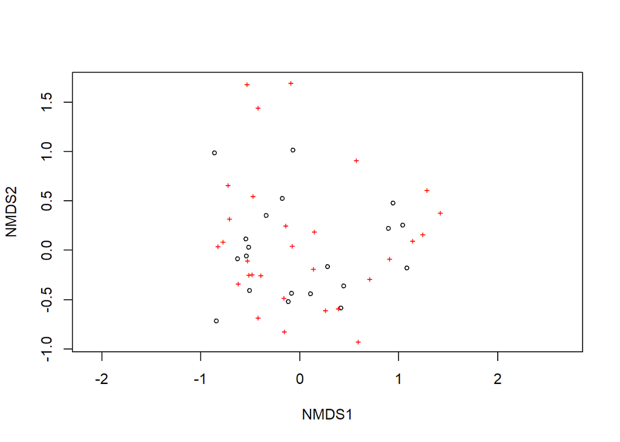

```r
plot(MDS)
```

Este grafico es muy feo, vamos a hacer un *ggplot!*

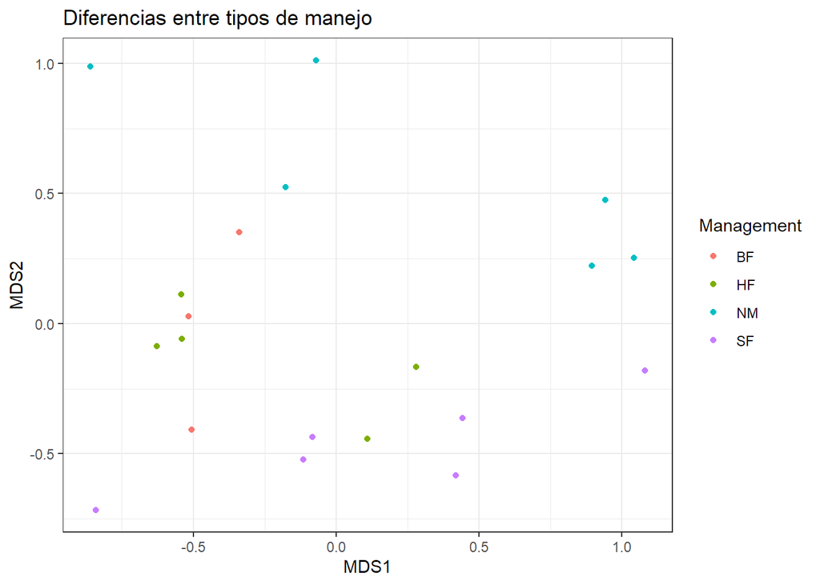

```r
DF<- MDS$points %>% as.data.frame() %>% bind_cols(dune.env)

ggplot(DF, aes(MDS1, MDS2, col=Management))+
  geom_point()+
  labs(title = "Diferencias entre tipos de manejo")+
  theme_bw()
```

Vemos que los puntos de *BF* y *HF* se agrupan, lo que indica que hay diferencias en estos grupos frente a todo el conjunto.

En cuanto al tipo de uso tenemos

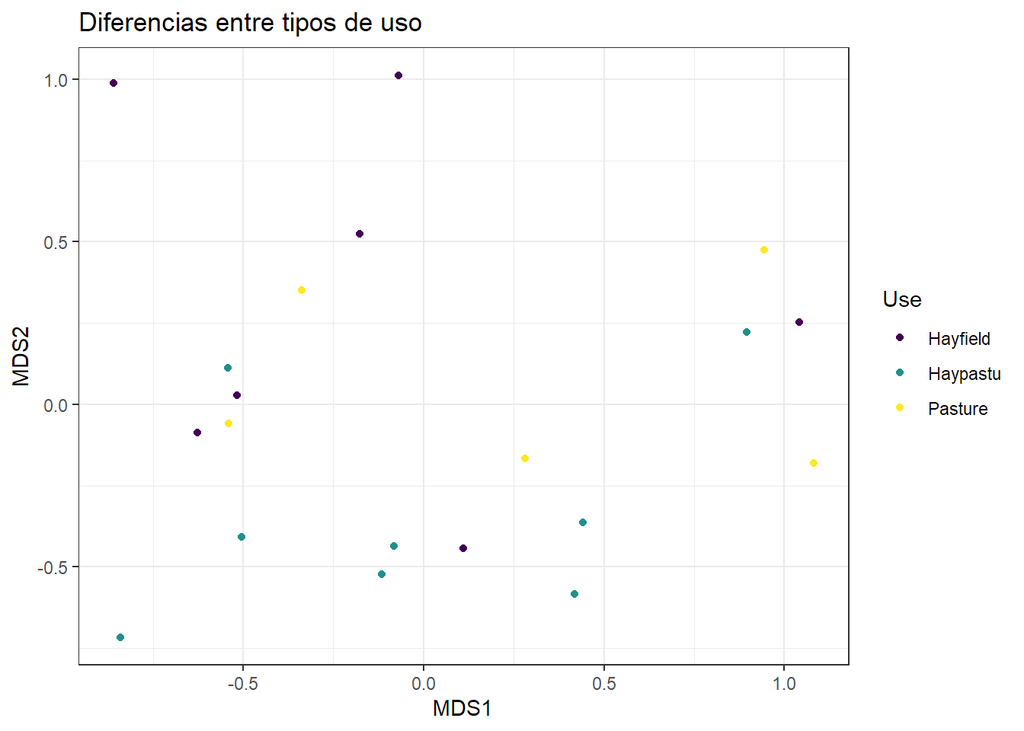

```r
ggplot(DF, aes(MDS1, MDS2, col=Use))+
  geom_point()+
  labs(title = "Diferencias entre tipos de uso")+
  theme_bw()
```

En este caso vemos que los puntos de los grupos estan dispersos, luego no se evidencia diferencia.

#### Transformaciones en MDS

Cuando tenemos comunidades balanceadas en numero de especies la reduccion de dimensionalidad no tiene mucho problema, pero que pasa si tenemos una o varias especies dominantes con una gran cantidad de registros? en este caso hay que hacer transformaciones para balancear los pesos antes de realizar el analisis de reduccion de dimensionalidad.

```r
dune2<- dune
dune2[1,1]<-100 #cambiamos el valor de las observaciones del sitio1 para la primera especie por 100

MDS2<- metaMDS(dune2)
```

```
## Square root transformation
## Wisconsin double standardization
## *** Solution reached
```

La funcion **metaMDS** realiza una transformacion de raiz cuadrada y una estandarizacion doble de *Wisconsin* de forma automatica. Se recomienda hacer las transformaciones de forma manual para tener claridad metodologica en el proceso.

### Que variables influencian la diferencia entre comunidades?

Vamos a ajustar un modelo que nos permita identificar las variables que causan diferencias entre las comunidades.

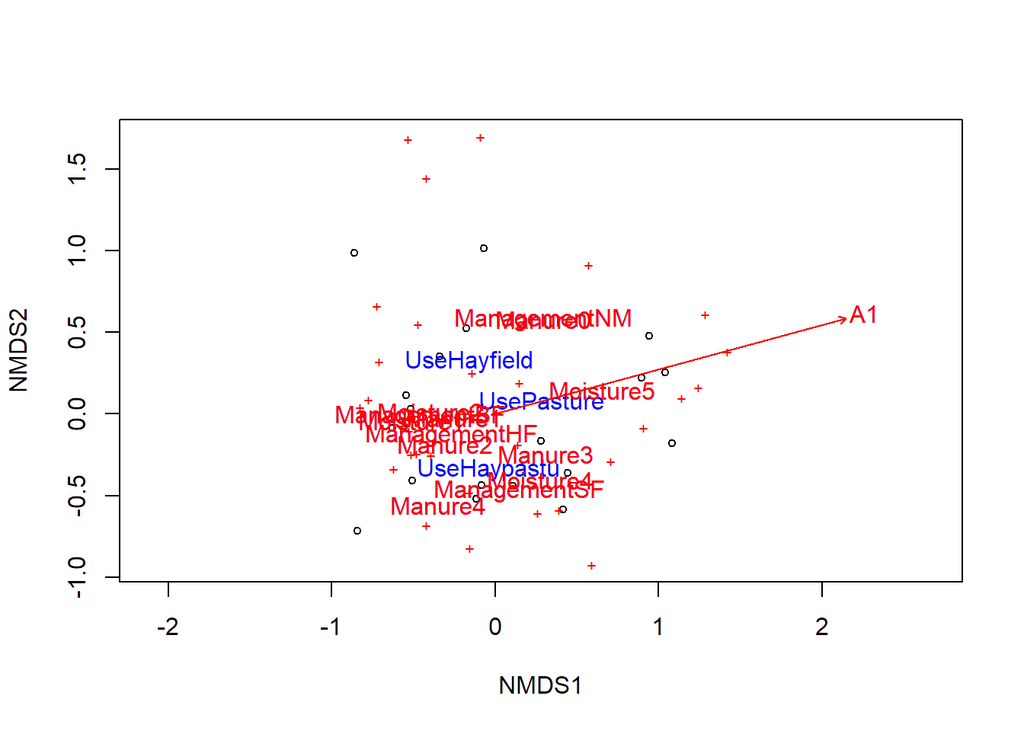

```r
Fit<- envfit(MDS, dune.env, perm=999)
plot(MDS)
plot(Fit)
plot(Fit, p.max=0.05, col="red")
```

En rojo podemos ver las variables que son significativas